fossil

# Gene set modules, dug back up.

The authors' R code is lost. We rebuilt every module from the paper as the R package gseamod, reran the simulation study (100 data sets) and redid the p53 and Hedenfalk analyses. Of 42 results we tried, 19 came back within their tolerance as printed, 7 agree, 8 partly and 8 differ.

See every result

## Install gseamod

R package

```
install.packages("remotes")
remotes::install_github("jeonglab-bcm/fossil/PMC2661051/package")
```

It needs R 4.3 or later and the Bioconductor package limma (installed by `remotes` from the `biocViews` field), fdrtool and corpcor from CRAN, and, for the globaltest track only, Bioconductor's globaltest.

[README](https://github.com/jeonglab-bcm/fossil/blob/main/PMC2661051/package/README.md) [Tutorial](https://github.com/jeonglab-bcm/fossil/blob/main/PMC2661051/package/tutorial/TUTORIAL.md)

## Tables 2 to 7

Each rate is the share of 100 simulated data sets in which a set was significant at p <= 0.05. Neither the paper's seeds nor its code survive, so a rate matches when it lies in the 99% band for two shares of 100.

Partly agreeson review

Table 2. Detection rates (share of 100 data sets with p <= 0.05): gene-level statistic and transformation; mean, resampling. Paper / ours; * outside the Monte Carlo band. 135 of 135 values within the band.

| set | none t | none mod.t | none corr | sq t | sq mod.t | sq corr | rank sq t | rank sq mod.t | rank sq corr | binary t | binary mod.t | binary corr | lfdr t | lfdr mod.t | lfdr corr |
| --- | --- | --- | --- | --- | --- | --- | --- | --- | --- | --- | --- | --- | --- | --- | --- |
| set 1 | 0.94 / 0.89 | 0.94 / 0.90 | 0.94 / 0.91 | 0.63 / 0.59 | 0.67 / 0.60 | 0.74 / 0.64 | 0.84 / 0.73 | 0.84 / 0.74 | 0.84 / 0.73 | 0.62 / 0.55 | 0.61 / 0.54 | 0.55 / 0.55 | 0.49 / 0.48 | 0.48 / 0.45 | 0.46 / 0.42 |
| set 2 | 1.00 / 1.00 | 1.00 / 1.00 | 1.00 / 1.00 | 0.90 / 0.90 | 0.92 / 0.94 | 0.95 / 0.96 | 1.00 / 0.98 | 1.00 / 0.98 | 1.00 / 0.98 | 0.81 / 0.79 | 0.87 / 0.86 | 0.73 / 0.81 | 0.77 / 0.73 | 0.78 / 0.76 | 0.71 / 0.65 |
| set 3 | 0.00 / 0.00 | 0.00 / 0.00 | 0.00 / 0.00 | 0.00 / 0.00 | 0.01 / 0.00 | 0.01 / 0.01 | 0.01 / 0.02 | 0.01 / 0.00 | 0.01 / 0.02 | 0.01 / 0.00 | 0.00 / 0.00 | 0.01 / 0.00 | 0.00 / 0.00 | 0.00 / 0.00 | 0.00 / 0.01 |
| set 4 | 0.79 / 0.70 | 0.81 / 0.76 | 0.83 / 0.77 | 0.40 / 0.37 | 0.44 / 0.39 | 0.50 / 0.41 | 0.54 / 0.46 | 0.54 / 0.49 | 0.54 / 0.46 | 0.38 / 0.34 | 0.44 / 0.40 | 0.34 / 0.34 | 0.32 / 0.30 | 0.36 / 0.30 | 0.32 / 0.30 |
| set 5 | 0.95 / 0.87 | 0.96 / 0.85 | 0.95 / 0.86 | 0.34 / 0.40 | 0.41 / 0.46 | 0.44 / 0.48 | 0.38 / 0.46 | 0.41 / 0.48 | 0.38 / 0.46 | 0.27 / 0.29 | 0.33 / 0.32 | 0.20 / 0.29 | 0.23 / 0.26 | 0.26 / 0.31 | 0.20 / 0.24 |
| set 6 | 0.00 / 0.00 | 0.00 / 0.00 | 0.00 / 0.00 | 0.86 / 0.78 | 0.85 / 0.80 | 0.88 / 0.85 | 0.95 / 0.89 | 0.96 / 0.90 | 0.95 / 0.89 | 0.83 / 0.76 | 0.85 / 0.77 | 0.76 / 0.76 | 0.71 / 0.64 | 0.66 / 0.67 | 0.69 / 0.62 |
| set 7 | 0.01 / 0.01 | 0.01 / 0.00 | 0.00 / 0.00 | 0.99 / 1.00 | 1.00 / 1.00 | 1.00 / 1.00 | 1.00 / 1.00 | 1.00 / 1.00 | 1.00 / 1.00 | 1.00 / 1.00 | 1.00 / 1.00 | 0.99 / 1.00 | 0.99 / 0.97 | 0.99 / 0.95 | 0.95 / 0.90 |
| set 8 | 0.00 / 0.00 | 0.00 / 0.00 | 0.00 / 0.00 | 0.70 / 0.53 | 0.70 / 0.57 | 0.75 / 0.65 | 0.74 / 0.71 | 0.75 / 0.70 | 0.74 / 0.71 | 0.63 / 0.51 | 0.66 / 0.57 | 0.58 / 0.51 | 0.61 / 0.46 | 0.60 / 0.47 | 0.55 / 0.48 |
| set 9 | 0.00 / 0.00 | 0.01 / 0.00 | 0.00 / 0.00 | 0.81 / 0.84 | 0.90 / 0.92 | 0.89 / 0.91 | 0.80 / 0.84 | 0.82 / 0.84 | 0.80 / 0.84 | 0.71 / 0.72 | 0.73 / 0.81 | 0.65 / 0.72 | 0.74 / 0.74 | 0.75 / 0.78 | 0.66 / 0.67 |

Table 3. Gene set statistics; squared moderated t, resampling. Paper / ours; * outside the Monte Carlo band. 51 of 54 values within the band.

| set | mean | maxmean | median | ES | cond. FDR | Wilcoxon |
| --- | --- | --- | --- | --- | --- | --- |
| set 1 | 0.67 / 0.60 | 0.67 / 0.60 | 0.82 / 0.73 | 0.56 / 0.50 | 0.68 / 0.66 | 0.84 / 0.74 |
| set 2 | 0.92 / 0.94 | 0.93 / 0.94 | 0.98 / 0.96 | 0.65 / 0.63 | 0.94 / 0.84 | 1.00 / 0.98 |
| set 3 | 0.01 / 0.00 | 0.01 / 0.00 | 0.00 / 0.02 | 0.00 / 0.00 | 0.01 / 0.09 | 0.01 / 0.00 |
| set 4 | 0.44 / 0.39 | 0.45 / 0.39 | 0.57 / 0.53 | 0.35 / 0.34 | 0.45 / 0.39 | 0.54 / 0.49 |
| set 5 | 0.41 / 0.46 | 0.41 / 0.46 | 0.32 / 0.48 | 0.22 / 0.27 | 0.42 / 0.27 | 0.41 / 0.48 |
| set 6 | 0.85 / 0.80 | 0.86 / 0.80 | 0.94 / 0.89 | 0.80 / 0.68 | 0.85 / 0.79 | 0.96 / 0.90 |
| set 7 | 1.00 / 1.00 | 1.00 / 1.00 | 1.00 / 1.00 | 0.99 / 0.97 | 1.00 / 1.00 | 1.00 / 1.00 |
| set 8 | 0.70 / 0.57 | 0.71 / 0.57 | 0.78 / 0.73 | 0.65 / 0.44 * | 0.84 / 0.53 * | 0.74 / 0.70 |
| set 9 | 0.90 / 0.92 | 0.86 / 0.92 | 0.81 / 0.77 | 0.69 / 0.76 | 0.99 / 0.84 * | 0.80 / 0.84 |

Table 4. Significance assessment; mean of squared moderated t. Paper / ours; * outside the Monte Carlo band. 36 of 36 values within the band.

| set | parametric | resampling | permutation | restand. |
| --- | --- | --- | --- | --- |
| set 1 | 0.82 / 0.75 | 0.67 / 0.60 | 0.59 / 0.55 | 0.66 / 0.60 |
| set 2 | 1.00 / 1.00 | 0.92 / 0.94 | 1.00 / 1.00 | 0.92 / 0.94 |
| set 3 | 0.03 / 0.06 | 0.01 / 0.00 | 0.06 / 0.13 | 0.01 / 0.00 |
| set 4 | 0.60 / 0.62 | 0.44 / 0.39 | 0.51 / 0.47 | 0.43 / 0.38 |
| set 5 | 0.85 / 0.95 | 0.41 / 0.46 | 0.90 / 0.95 | 0.41 / 0.45 |
| set 6 | 0.96 / 0.89 | 0.85 / 0.80 | 0.83 / 0.72 | 0.84 / 0.80 |
| set 7 | 1.00 / 1.00 | 1.00 / 1.00 | 1.00 / 1.00 | 1.00 / 1.00 |
| set 8 | 0.90 / 0.85 | 0.70 / 0.57 | 0.79 / 0.69 | 0.68 / 0.55 |
| set 9 | 0.99 / 1.00 | 0.90 / 0.92 | 1.00 / 1.00 | 0.87 / 0.92 |

Table 5. globaltest. Paper / ours; * outside the Monte Carlo band. 35 of 36 values within the band.

| set | parametric | resampling | permutation | restand. |
| --- | --- | --- | --- | --- |
| set 1 | 0.59 / 0.54 | 0.66 / 0.61 | 0.61 / 0.52 | 0.63 / 0.60 |
| set 2 | 1.00 / 1.00 | 0.94 / 0.92 | 1.00 / 1.00 | 0.93 / 0.92 |
| set 3 | 0.02 / 0.13 * | 0.00 / 0.00 | 0.05 / 0.12 | 0.00 / 0.00 |
| set 4 | 0.46 / 0.45 | 0.44 / 0.41 | 0.49 / 0.46 | 0.44 / 0.37 |
| set 5 | 0.85 / 0.94 | 0.42 / 0.41 | 0.91 / 0.93 | 0.43 / 0.40 |
| set 6 | 0.82 / 0.71 | 0.85 / 0.81 | 0.80 / 0.71 | 0.84 / 0.81 |
| set 7 | 1.00 / 1.00 | 1.00 / 1.00 | 1.00 / 1.00 | 1.00 / 1.00 |
| set 8 | 0.74 / 0.65 | 0.69 / 0.57 | 0.76 / 0.67 | 0.68 / 0.55 |
| set 9 | 0.99 / 1.00 | 0.86 / 0.87 | 1.00 / 1.00 | 0.89 / 0.86 |

Table 6. Hotelling T2 with a shrinkage correlation. Paper / ours; * outside the Monte Carlo band. 25 of 27 values within the band.

| set | resampling | permutation | restand. |
| --- | --- | --- | --- |
| set 1 | 0.09 / 0.25 * | 0.18 / 0.33 | 0.08 / 0.25 * |
| set 2 | 0.92 / 0.92 | 1.00 / 1.00 | 0.92 / 0.93 |
| set 3 | 0.01 / 0.00 | 0.05 / 0.09 | 0.01 / 0.00 |
| set 4 | 0.06 / 0.10 | 0.16 / 0.25 | 0.05 / 0.11 |
| set 5 | 0.41 / 0.40 | 0.91 / 0.90 | 0.40 / 0.40 |
| set 6 | 0.25 / 0.29 | 0.26 / 0.34 | 0.22 / 0.29 |
| set 7 | 1.00 / 1.00 | 1.00 / 1.00 | 1.00 / 1.00 |
| set 8 | 0.25 / 0.14 | 0.51 / 0.34 | 0.25 / 0.15 |
| set 9 | 0.89 / 0.84 | 1.00 / 0.98 | 0.87 / 0.84 |

Table 7. Hedenfalk sets with p <= 0.01 (mean of squared moderated t, permutation). 27 of 42 values as printed or within the Monte Carlo band of 1000 permutations.

| Set | paper | ours |
| --- | --- | --- |
| sets with p <= 0.01 | 41 | 56 |
| 1. breast_cancer_estrogen_signalling | 0.000 | 0.000 |
| 2. cell_surface_receptor_linked_signal_transduction | 0.000 | 0.003 |
| 3. insulin_signalling | 0.000 | 0.006 |
| 4. p53_signalling | 0.000 | 0.002 |
| 5. pparaPathway | 0.000 | 0.004 |
| 6. VOXPHOS | 0.000 | 0.000 |
| 7. RAP_UP | 0.000 | 0.016 |
| 8. PROLIF_GENES | 0.000 | 0.000 |
| 9. UPREG_BY_HOXA9 | 0.000 | 0.013 |
| 10. cell_adhesion | 0.001 | 0.003 |
| 11. CR_CAM | 0.001 | 0.001 |
| 12. CR_DEATH | 0.001 | 0.008 |
| 13. il2rbPathway | 0.001 | 0.001 |
| 14. ST_Tumor_Necrosis_Factor_Pathway (not among our 84 sets) | 0.001 | none |
| 15. tcrPathway | 0.001 | 0.024 |
| 16. HTERT_UP | 0.001 | 0.006 |
| 17. CBF_LEUKEMIA_DOWNING_AML | 0.001 | 0.325 |
| 18. CR_SIGNALLING | 0.002 | 0.016 |
| 19. ghPathway (not among our 84 sets) | 0.002 | none |
| 20. ST_B_Cell_Antigen_Receptor | 0.002 | 0.008 |
| 21. tpoPathway (not among our 84 sets) | 0.002 | none |
| 22. GO_0005739 | 0.002 | 0.000 |
| 23. LEU_UP | 0.002 | 0.044 |
| 24. Cell_Cycle | 0.003 | 0.000 |
| 25. GLUT_UP | 0.003 | 0.004 |
| 26. FRASOR_ER_DOWN | 0.003 | 0.009 |
| 27. ANDROGEN_UP_GENES | 0.003 | 0.000 |
| 28. fmlppathway (not among our 84 sets) | 0.004 | none |
| 29. hivnefPathway | 0.004 | 0.050 |
| 30. biopeptidesPathway | 0.005 | 0.011 |
| 31. cell_adhesion_molecule_activity | 0.005 | 0.000 |
| 32. SIG_InsulinReceptorPathwayInCardiacMyocytes | 0.005 | 0.000 |
| 33. ST_Integrin_Signaling_Pathway | 0.005 | 0.009 |
| 34. drug_resistance_and_metabolism | 0.006 | 0.000 |
| 35. ST_Differentiation_Pathway_in_PC12_Cells | 0.007 | 0.021 |
| 36. gleevecPathway | 0.008 | 0.005 |
| 37. DNA_DAMAGE_SIGNALLING | 0.009 | 0.000 |
| 38. ST_ERK1_ERK2_MAPK_Pathway | 0.009 | 0.010 |
| 39. mRNA_splicing (not among our 84 sets) | 0.010 | none |
| 40. nfatPathway | 0.010 | 0.002 |
| 41. HUMAN_CD34_ENRICHED_TF_JP | 0.010 | 0.000 |

Table 2, Table 4 and Table 5 came back within Monte Carlo error but for one rate, Table 5's set 3 parametric, which is 0.050 on 400 more data sets. Our cond. FDR misses sets 8 and 9 of Table 3, and our Hotelling finds the correlated set 1 more often than the paper's.

## Fig. 2

Fig. 2. p53 data, squared moderated t. Left: number of significant gene sets against the p-value cutoff for eight gene set statistics, resampling (black) and permutation (blue). Right: the counts at cutoff 0.01.

Partly agrees

Published

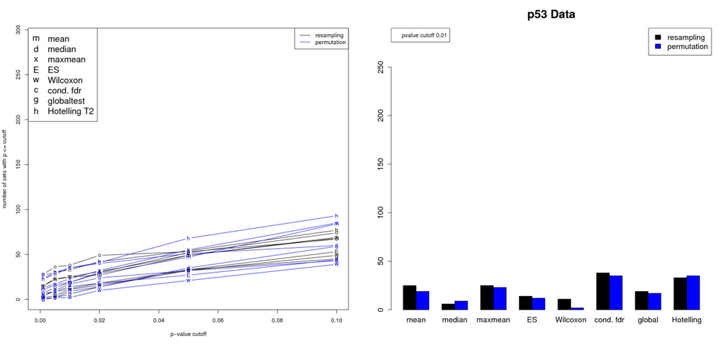

Our run

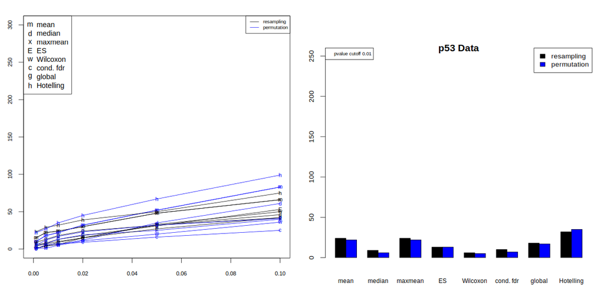

**Fig. 2 right, p53 sets with p <= 0.01**

9 of 16 values, Partly agrees

9 of 16 bars within one set: Hotelling (32 and 35 against 33 and 35), globaltest, ES and maxmean come back. Cond. FDR finds 10 and 7 sets against 38 and 35. On p53, fdrtool sets the local fdr of every gene to 1 (no gene below 0.2), so our cond. FDR keeps only its membership-probability part and loses power; in the simulation the fdr is informative and the same statistic lands close (Table 3). Wilcoxon, median and the mean by permutation differ by 3 to 5 sets.

## Fig. 3

Fig. 3. The 290 p53 gene sets. Top: histogram of the mean pairwise correlation in each set. Bottom: of the mean absolute correlation.

Partly agrees

Published

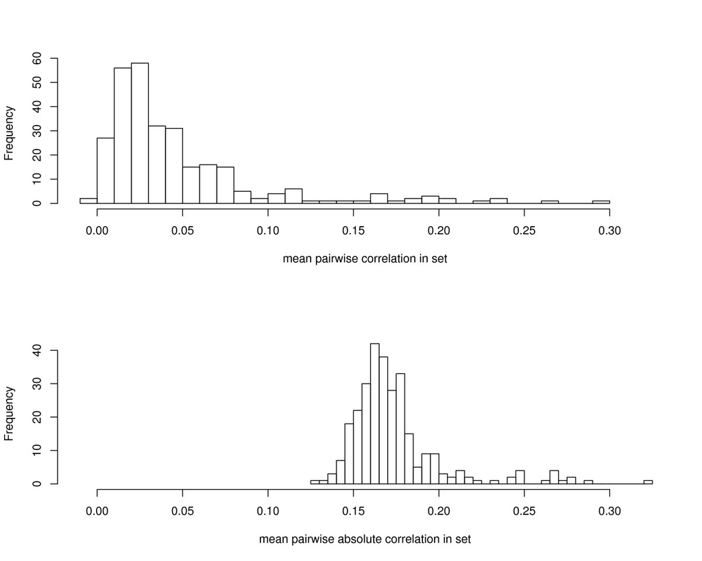

Our run

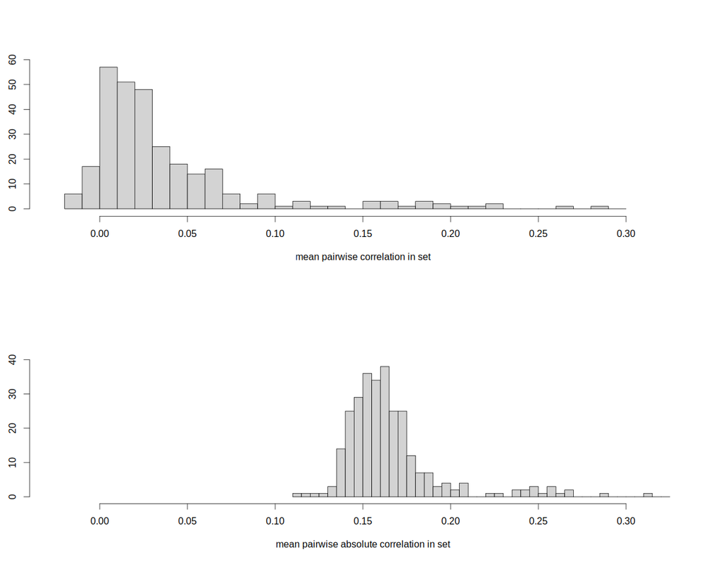

**Fig. 3 top, mean pairwise correlation of the 290 p53 sets**

8 of 31 values, Partly agrees

**Fig. 3 bottom, mean absolute pairwise correlation**

11 of 40 values, Partly agrees

8 of 31 bins equal: our correlations are lower (median 0.022 against about 0.03 in the paper, 6 sets below -0.01 where the paper has none). The paper does not say on which data the correlations were computed; three variants each improve one measure and none closes the gap. 11 of 40 bins equal; our histogram sits about 0.005 lower (median 0.160 against about 0.166).

## Fig. 4

Fig. 4. Hedenfalk data, as Fig. 2.

Differson review

Published

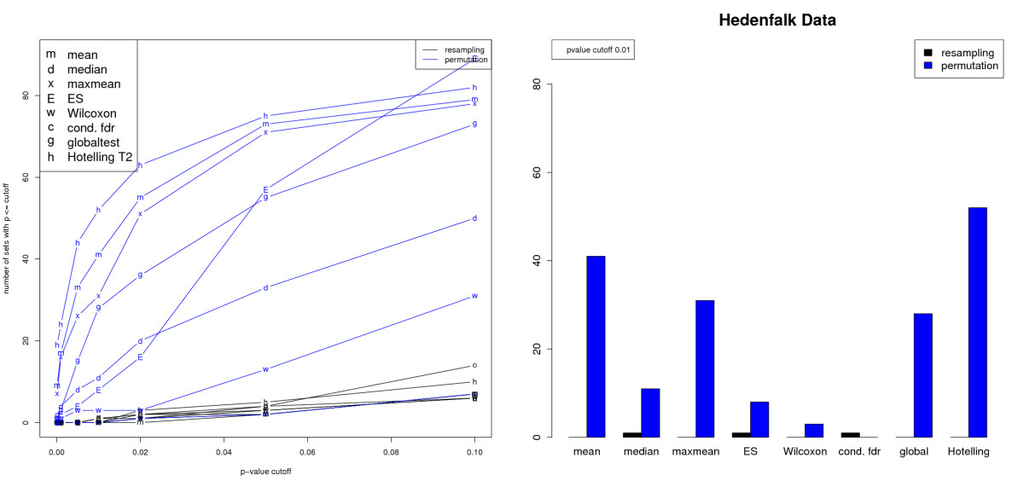

Our run

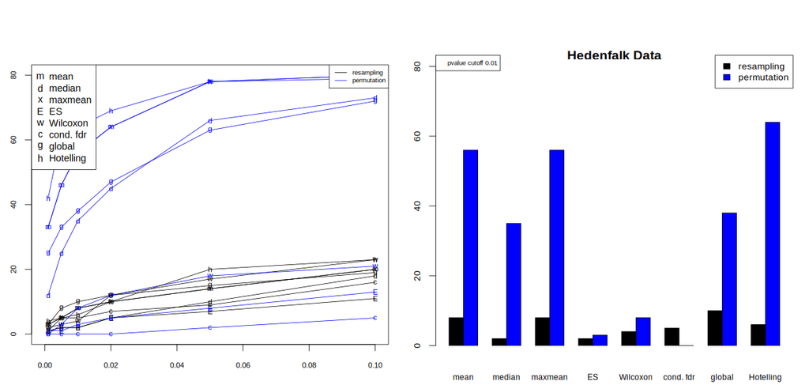

**Fig. 4 right, Hedenfalk sets with p <= 0.01**

1 of 16 values, Differs

1 of 16 bars equal. The pattern comes back (resampling finds few sets, permutation many; Hotelling, mean, maxmean and globaltest highest; cond. FDR none by permutation), but our counts are higher for 14 of 16 bars (ES by permutation is lower, 3 against 8; cond. FDR by permutation is 0 in both): mean 56 against 41 by permutation, 8 against 0 by resampling. Our gene mapping and set catalogue differ from the paper's (84 sets, not 89).

## Every result

Every figure, table and claim of the paper, with its verdict from results.json. Exact for a simulated rate means within its Monte Carlo band.

Result

Verdict

Measure

Why

Table 1, methods in the literature

Not attempted

A list of published methods and their references; nothing to compute.

Fig. 1, the five modules

Not attempted

A diagram of the framework; it is the structure of the package gseamod.

Text: 3 x 5 x 6 x 3 - 9 = 261 variants

Exact

1 of 1 values

- 3 gene-level statistics x 5 transformations x 6 gene set statistics x 3 significance assessments - 9 (ES with binary): paper 261, ours **261**

Table 2, gene-level statistic x transformation (mean, resampling)

Partly agreeson review

135 of 135 values

Every rate lies in the 99% Monte Carlo band (135 of 135), but two settings are not in the paper: the binary transformation's cutoff (two-sided p <= 0.05, chosen because a local fdr <= 0.2 rule called almost no gene) and the local fdr null. The reviewer set the verdict to partly.

Table 3, gene set statistics (squared mod.t, resampling)

Partly agrees

51 of 54 values

51 of 54 rates agree. Cond. FDR misses sets 8 and 9 (0.53 and 0.84 against 0.84 and 0.99) and ES misses set 8 (0.44 against 0.65): the paper does not define its cond. FDR statistic or its ES ordering on squared scores.

Table 4, significance assessment (mean of squared mod.t)

Exact

36 of 36 values

Table 5, globaltest

Agreeson review

35 of 36 values

35 of 36 rates agree. The parametric false positive rate of set 3 is 0.13 in our 100 data sets against 0.02; on 400 more data sets it is 0.050, so the 0.13 is chance in our sample (the same data sets also give 0.12 by permutation).

Table 6, Hotelling T2 with a shrinkage correlation

Partly agrees

25 of 27 values

25 of 27 rates agree. Set 1 is found more often than in the paper (0.25 against 0.09 by resampling and 0.25 against 0.08 by restandardization): the paper does not say how its shrinkage correlation was estimated.

Text check: Tables 2, 3 and 4 print the same squared mod.t / mean / resampling cell

Exact

9 of 9 values

- set1: Table 2 squared mod.t = Table 3 mean = Table 4 resampling: paper yes, ours **yes**
- set2: Table 2 squared mod.t = Table 3 mean = Table 4 resampling: paper yes, ours **yes**
- set3: Table 2 squared mod.t = Table 3 mean = Table 4 resampling: paper yes, ours **yes**
- set4: Table 2 squared mod.t = Table 3 mean = Table 4 resampling: paper yes, ours **yes**
- set5: Table 2 squared mod.t = Table 3 mean = Table 4 resampling: paper yes, ours **yes**
- set6: Table 2 squared mod.t = Table 3 mean = Table 4 resampling: paper yes, ours **yes**
- set7: Table 2 squared mod.t = Table 3 mean = Table 4 resampling: paper yes, ours **yes**
- set8: Table 2 squared mod.t = Table 3 mean = Table 4 resampling: paper yes, ours **yes**
- set9: Table 2 squared mod.t = Table 3 mean = Table 4 resampling: paper yes, ours **yes**

Text: untransformed statistics miss sets 6 to 9

Exact

1 of 1 values

- Untransformed statistics miss sets 6 to 9 (every rate <= 0.05): paper yes, ours **yes**

Text: squaring finds sets 6 to 9

Exact

1 of 1 values

- Squared statistics find sets 6 to 9 (every rate >= 0.5): paper yes, ours **yes**

Text: squaring lowers sets 1, 2, 4 and 5 slightly

Exact

1 of 1 values

- Squaring lowers the rates of sets 1, 2, 4 and 5 (or keeps them): paper yes, ours **yes**

Text: rank squared performs best overall

Agrees

1 of 1 values

- Rank squared has the highest mean rate over the eight non-null sets: paper yes, ours **yes**

Text: (rank) squared beats binary and local fdr

Agrees

1 of 1 values

- Squared and rank squared beat binary and local fdr (mean rate): paper yes, ours **yes**

Text: median and Wilcoxon beat the mean on correlated sets

Exact

1 of 1 values

- Median and Wilcoxon beat the mean on every correlated set (1, 4, 6, 8): paper yes, ours **yes**

Text: with permutation that advantage vanishes (data not shown)

Exact

1 of 1 values

- With permutation, median and Wilcoxon lose their edge over the mean on the correlated sets (data not shown in the paper): paper yes, ours **yes**

Text: ES is weaker than the mean

Exact

1 of 1 values

- ES has a lower mean rate than the mean statistic: paper yes, ours **yes**

Text: the parametric null gives the best rates

Exact

1 of 1 values

- The parametric null gives the highest mean rate over the non-null sets: paper yes, ours **yes**

Text: restandardization performs like resampling

Exact

1 of 1 values

- Restandardization is within 0.05 of resampling on every set: paper yes, ours **yes**

Text: permutation detects uncorrelated sets more easily

Exact

1 of 1 values

- Permutation detects the uncorrelated sets at least as often as resampling: paper yes, ours **yes**

Text: globaltest is very close to the mean of squared statistics

Differs

0 of 1 values

- globaltest is within 0.05 of the mean of squared moderated t (resampling, permutation, restandardization): paper yes, ours **no**

Our largest difference is 0.06 (set 9, restandardization: 0.86 against 0.92), against the 0.05 we took as close; the paper's own tables differ by at most 0.04. Both are within Monte Carlo error of two shares of 100.

Text: Hotelling hardly detects the correlated sets

Exact

1 of 1 values

- Hotelling (resampling) detects every correlated set less often than every uncorrelated set: paper yes, ours **yes**

Text: Hotelling improves with permutation

Exact

1 of 1 values

- Hotelling detects every set at least as often with permutation as with resampling: paper yes, ours **yes**

Text: p53 data, 50 cell lines, 8,768 genes, 290 sets of 15 to 321 genes

Agrees

8 of 8 values

- cell lines: paper 50, ours **50**
- wild type: paper 17, ours **17**
- mutant: paper 33, ours **33**
- probe sets on the HG-U95Av2 file: paper 12625, ours **12625**
- genes after filtering: paper 8768, ours **8768**
- gene sets of 15 to 500 genes: paper 290, ours **290**
- smallest set: paper 15, ours **15**
- largest set: paper 321, ours **321**

Fig. 2 left, significant p53 sets against the cutoff

Not attempted

Drawn and overlaid, not scored: sixteen curves with letter markers overlap, so their values cannot be read off the figure. The cutoff 0.01 is scored through the right panel, and the ranking claims are scored as text.

Fig. 2 right, p53 sets with p <= 0.01

Partly agrees

9 of 16 values

- mean, resampling: paper 25, ours **24**
- mean, permutation: paper 19, ours **22**
- median, resampling: paper 6, ours **9**
- median, permutation: paper 9, ours **6**
- maxmean, resampling: paper 25, ours **24**
- maxmean, permutation: paper 23, ours **22**
- es, resampling: paper 14, ours **13**
- es, permutation: paper 12, ours **13**
- wilcoxon, resampling: paper 11, ours **6**
- wilcoxon, permutation: paper 2, ours **5**
- condfdr, resampling: paper 38, ours **10**
- condfdr, permutation: paper 35, ours **7**
- globaltest, resampling: paper 19, ours **18**
- globaltest, permutation: paper 17, ours **17**
- hotelling, resampling: paper 33, ours **32**
- hotelling, permutation: paper 35, ours **35**

9 of 16 bars within one set: Hotelling (32 and 35 against 33 and 35), globaltest, ES and maxmean come back. Cond. FDR finds 10 and 7 sets against 38 and 35. On p53, fdrtool sets the local fdr of every gene to 1 (no gene below 0.2), so our cond. FDR keeps only its membership-probability part and loses power; in the simulation the fdr is informative and the same statistic lands close (Table 3). Wilcoxon, median and the mean by permutation differ by 3 to 5 sets.

Text: p53, Hotelling and cond. FDR find the most sets (resampling)

Differs

0 of 1 values

- p53, resampling: Hotelling and cond. FDR find the most sets: paper yes, ours **no**

Hotelling finds the most sets as in the paper, but our cond. FDR finds few (see Fig. 2 right).

Text: p53, Hotelling and cond. FDR find the most sets (permutation)

Differs

0 of 1 values

- p53, permutation: Hotelling and cond. FDR find the most sets: paper yes, ours **no**

Hotelling finds the most sets as in the paper, but our cond. FDR finds few (see Fig. 2 right).

Text: p53, ES, median and Wilcoxon find the fewest sets (resampling)

Differs

0 of 1 values

- p53, resampling: ES, median and Wilcoxon find the fewest sets: paper yes, ours **no**

Our cond. FDR (10 sets) falls among the three lowest; without it median, Wilcoxon and ES are the three lowest as in the paper.

Text: p53, ES, median and Wilcoxon find the fewest sets (permutation)

Differs

0 of 1 values

- p53, permutation: ES, median and Wilcoxon find the fewest sets: paper yes, ours **no**

Our cond. FDR (7 sets) falls among the three lowest; without it median, Wilcoxon and ES are the three lowest as in the paper.

Fig. 3 top, mean pairwise correlation of the 290 p53 sets

Partly agrees

8 of 31 values

8 of 31 bins equal: our correlations are lower (median 0.022 against about 0.03 in the paper, 6 sets below -0.01 where the paper has none). The paper does not say on which data the correlations were computed; three variants each improve one measure and none closes the gap.

Fig. 3 bottom, mean absolute pairwise correlation

Partly agrees

11 of 40 values

11 of 40 bins equal; our histogram sits about 0.005 lower (median 0.160 against about 0.166).

Text: correlations within p53 sets are comparatively weak

Agrees

1 of 1 values

- median over the 290 sets of the mean pairwise correlation below 0.1 ("comparatively weak"): paper yes, ours **yes**

Text: Hedenfalk data, 7 BRCA1 and 8 BRCA2, 2,200 mapped genes, 89 sets

Partly agrees

3 of 5 values

- BRCA1 patients: paper 7, ours **7**
- BRCA2 patients: paper 8, ours **8**
- genes on the array: paper 3226, ours **3226**
- genes mapped uniquely to a UniGene symbol: paper 2200, ours **2233**
- gene sets: paper 89, ours **84**

Samples and array size agree; we map 2,233 genes (2,200 in the paper) and keep 84 sets (89). The paper's UniGene build and set selection are not given.

Fig. 4 left, significant Hedenfalk sets against the cutoff

Differson review

Drawn and overlaid, not scored, as Fig. 2 left: the overlapping letter markers cannot be read.

Fig. 4 right, Hedenfalk sets with p <= 0.01

Differson review

1 of 16 values

- mean, resampling: paper 0, ours **8**
- mean, permutation: paper 41, ours **56**
- median, resampling: paper 1, ours **2**
- median, permutation: paper 11, ours **35**
- maxmean, resampling: paper 0, ours **8**
- maxmean, permutation: paper 31, ours **56**
- es, resampling: paper 1, ours **2**
- es, permutation: paper 8, ours **3**
- wilcoxon, resampling: paper 0, ours **4**
- wilcoxon, permutation: paper 3, ours **8**
- condfdr, resampling: paper 1, ours **5**
- condfdr, permutation: paper 0, ours **0**
- globaltest, resampling: paper 0, ours **10**
- globaltest, permutation: paper 28, ours **38**
- hotelling, resampling: paper 0, ours **6**
- hotelling, permutation: paper 52, ours **64**

1 of 16 bars equal. The pattern comes back (resampling finds few sets, permutation many; Hotelling, mean, maxmean and globaltest highest; cond. FDR none by permutation), but our counts are higher for 14 of 16 bars (ES by permutation is lower, 3 against 8; cond. FDR by permutation is 0 in both): mean 56 against 41 by permutation, 8 against 0 by resampling. Our gene mapping and set catalogue differ from the paper's (84 sets, not 89).

Text: Hedenfalk, resampling finds very few sets

Differs

0 of 1 values

- Hedenfalk: resampling finds very few sets (at most 2) with every statistic: paper yes, ours **no**

Our resampling finds 2 to 10 sets per statistic at 0.01 against 0 or 1 in the paper: few compared with permutation, but more than 2 for every statistic except median and ES (2 each).

Text: Hedenfalk, Hotelling, mean, maxmean and globaltest find the most sets

Exact

1 of 1 values

- Hedenfalk, permutation: Hotelling, mean, maxmean and globaltest find the most sets: paper yes, ours **yes**

Text: Hedenfalk, cond. FDR is conservative

Exact

1 of 1 values

- Hedenfalk, permutation: cond. FDR is among the four statistics that find the fewest sets: paper yes, ours **yes**

Table 7, Hedenfalk sets with p <= 0.01 (mean, permutation)

Partly agrees

27 of 42 values

27 of the 41 sets come back at the printed p within Monte Carlo error, breast_cancer_estrogen_signalling first at 0.000 as in the paper; 5 of the paper's sets are not in our 84, and we find 56 sets at p <= 0.01 against 41.

Text: breast_cancer_estrogen_signalling first by the mean, outside the ES top 20

Exact

2 of 2 values

- breast_cancer_estrogen_signalling: rank by the mean (1 + sets with a smaller p): paper 1, ours **1**
- breast_cancer_estrogen_signalling: outside the top 20 by ES: paper yes, ours **yes**

Table 8, contingency table notation (Appendix)

Not attempted

Notation for the 2 x 2 table of overrepresentation analysis.

Main claim: the mean of squared mod.t beats GSEA's ES

Exact

1 of 1 values

- Main claim: the mean of squared moderated t beats the ES score: paper yes, ours **yes**

Main claim: the mean of squared mod.t beats Hotelling

Exact

1 of 1 values

- Main claim: the mean of squared moderated t (permutation) beats Hotelling (permutation): paper yes, ours **yes**

Claims recomputed from the paper's own tables

Agrees

22 of 22 claims come back from the paper's own tables and figure bars

R package gseamod and its tutorial

Agrees

R package gseamod: R CMD check OK; tests 11 passed, 0 failed, 0 skipped; tutorial rendering equals the committed TUTORIAL.md (figures by name)

The main claims hold: the mean of squared moderated t beats ES and Hotelling; Tables 4 and 5 come back, and Tables 2, 3 and 6 partly (Table 2 has every rate in the Monte Carlo band; the reviewer set it to partly for the chosen binary cutoff). Of the claims that do not match, four come from our cond. FDR, which is not the paper's, one from the Hedenfalk gene mapping and one from Monte Carlo error (globaltest against the mean).

## What came back

**The modules**

Three gene-level statistics, five transformations, six gene set statistics, four significance assessments, globaltest and Hotelling, as the R package gseamod.

**The simulation**

206 of 207 rates of Tables 2, 4 and 5 within Monte Carlo error; 51 of 54 in Table 3 and 25 of 27 in Table 6.

**The p53 data**

The paper's filter on GSEA's collapsed file gives exactly 8,768 genes and 290 sets of 15 to 321 genes.

**Fig. 2**

Hotelling, globaltest, ES and maxmean within one set of the published bars at cutoff 0.01.

**Table 7**

breast_cancer_estrogen_signalling first again, and 27 of the 41 sets at their printed p.

## What stayed buried

- The paper's cond. FDR statistic: neither of two readings of it gives its Table 3 numbers, and the mean-of-fdr reading also misses Fig. 2.
- Its Hotelling correlation estimate: ours finds the correlated set 1 more often.
- Its Hedenfalk gene mapping and its 89 sets: ours has 2,233 genes and 84 sets, and finds more sets.
- The data behind Fig. 3: our within-set correlations run a little lower.

The main claims hold: the mean of squared moderated t beats ES and Hotelling; Tables 4 and 5 come back, and Tables 2, 3 and 6 partly (Table 2 has every rate in the Monte Carlo band; the reviewer set it to partly for the chosen binary cutoff). Of the claims that do not match, four come from our cond. FDR, which is not the paper's, one from the Hedenfalk gene mapping and one from Monte Carlo error (globaltest against the mean).

## What we matched

What we matched, and how.

**Tables 2 to 6**

Rates of 100 simulated data sets against the printed ones, each within a 99% band for two shares of 100.

**Figs 2 and 4**

Bars at cutoff 0.01 read off the original figure files through their tick marks.

**Fig. 3**

Histogram counts read off the same way; both sum to 290 sets.

**Text**

Each claim written as a comparison and checked first on the paper's own tables (22 of 22 hold there).

## The session

The reproduction was done by an AI agent, Claude Code, in one session. Every prompt, reply and tool call of it is published.

**Wall clock**

106 min

first message to last, waits included

**Human prompts**

7

messages typed by a person

**Tool calls**

305

18 of them in subagents

**Tokens**

98.7 M

every request, subagents included

Read the session [The raw files](https://github.com/jeonglab-bcm/fossil/tree/main/PMC2661051/session)